# Quantitative Genetics

AlphaSimR for Simulation

Felipe Ferrão

University of Florida – July, 2022

**Extra information**

- [HOS 6932 – Website](https://lfelipe-ferrao.github.io/class/survey/)
- About the [author](https://lfelipe-ferrao.github.io/)
- About the [UF/IFAS Plant Breeding](https://programs.ifas.ufl.edu/plant-breeding/)

# Introduction

In this section we are discussion the use of computational tools in quantitative genetics. With the advent of faster computers, geneticists are breeders can take advantage of simulations to answer some basic questions. For example:

- How many individuals do I need to start my breeding program?
- How many reps?
- What is the impact of genomic selection in my breeding program?
- How to define number of parents?
- What experimental design?
- What is the importance of different gene actions?

All these questions are underlying the practical implementations and genetic analyses, a fact that make breeding programs complex and costly. To shed light on breeder decisions we need an in-silico modelling framework, where we could present ideas, translate it in models and deploy results. In this sense, the AlphaSimR is an R package for stochastic simulations in plant and animal. The software provide a flexible framework and powerful tools to design and optimize breeding programs.

# Theory

## What is AlphaSimR ?

AlphaSimR is a large package with an extensive list of features.The package provides the ability to run simulations that correspond to common operation in a breeding program, including crossings and selection. There is no single way to construct a simulation in AlphaSimR. Most simulations follow a general structure consisting of four steps:

1. Creating Founder Haplotypes by simulating a genome and combining information from molecular and population genetics
2. Setting Simulation Parameters by simulating phenotypes using quantitative genetic theory
3. Modeling the Breeding Program, by making selection and using mating desing
4. Examining the Results

## Simulation Approach

### Founder Haplotypes

- The founder haplotypes are used to form the genome and genotypes of animals in the first generation
- A coalescent simulator (MaCS) is used to recreate the evolutionary history of a species (chr size, mutation and recombination rate, Ne )
- Burn-in period (historical intensive selection)
- `runMacs` will generate founder haplotypes using the MaCS theory.
- `SimParam` is used to set up global parameters about the genetic architecture of the trai, including the gene action under study (ex: additive)

### Base Population

- Based on the simulated genome we assembly individual genotypes
- Software will model genetic recombination during meiosis. Meiosis can be defined for diploid and polyploid species.
- Software will randomly pick chromosomes to generate full individual genomes to form a base population
- `newPop` is the main function that will use the haplotype as a reference to generate a base population

### Phenotype

- We need to simulate our trait based on quantitative genetics
- Genetic value: additive polygenic model
- Phenotypic value: add environmental noise to the genetic value
- Simulate heritability and correlation between traits
- Simulate interactions
- We can compute quantitative traits in autopolyploids
- `setPheno` is the main function to define phenotypic values

### Breeding Program

- Next step is to design breeding cycles by selecting the number of parents, crosses/mating, number of offsprings and selection method
- `selectInd` and `randCross` will simulate selections and crossings in a breeding program

### Metrics for breeding

- We need to check the genetic progress by computing the genetic gain, variances and selection accuracy
- `meanP` and `meanG` are both important functions to track the mean performance
- `varP` and `varG` are both important functions to track the genetic progress

# Hands-on

In this example we will we will simulate a generic breeding population, where we will select a single trait with moderate heritability. Some important points:

- Don’t worry about the R codes, there are some loops and functions that are useful to speed up the process.
- Focus on the results ! How selection can change variances and means.
- Focus on how the package is flexible to run breeding programs in different scenarios
- Along this course we will use similar information to compute the genetic progress and understand how some key genetic parameters (ex: heritability) have a key role on breeder’s decisions.

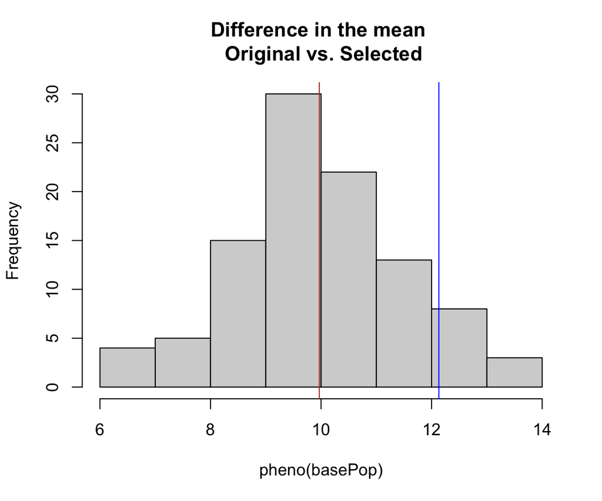

```r
library(AlphaSimR)
library(knitr)

# Load AlphaSimR, simulate founder genomes, and define a trait
founderGenomes = runMacs(nInd = 100,
                         nChr = 5,
                         segSites = 100,
                         species = "GENERIC")
SP = SimParam$new(founderGenomes)$addTraitA(nQtlPerChr = 100, mean = 10, var = 1)

# Base population and their phenotypes
basePop = newPop(founderGenomes)
heritability = 0.5
basePop = setPheno(basePop, h2 = heritability)

# Simulated data
basePopData = data.frame(id = basePop@id, pheno = pheno(basePop))

# Selecting the best individuals
nSelected = 20
basePopSelected = selectInd(pop = basePop,
                            nInd = nSelected,
                            use = "pheno")

# Plot results
hist(pheno(basePop), main="Difference in the mean \n Original vs. Selected")
abline(v=meanP(basePop), col="red")
abline(v=meanP(basePopSelected), col="blue")
```

```r
# Selection over the time
nGenerations = 10 + 1 # +1 to store starting generation
meanPAll = numeric(nGenerations)
varPAll = numeric(nGenerations)
meanGAll = numeric(nGenerations)
varGAll = numeric(nGenerations)
meanPSelected = numeric(nGenerations)
varPSelected = numeric(nGenerations)
meanGSelected = numeric(nGenerations)
varGSelected = numeric(nGenerations)

# Save the starting values
meanPAll[1] = meanP(basePop)
varPAll[1] = varP(basePop)
meanGAll[1] = meanG(basePop)
varGAll[1] = varG(basePop)
meanPSelected[1] = meanP(basePopSelected)
varPSelected[1] = varP(basePopSelected)
meanGSelected[1] = meanG(basePopSelected)
varGSelected[1] = varG(basePopSelected)


# Selection over many generations
newPopSelected = basePopSelected
for (generation in 1:(nGenerations - 1)) {
  # Cross parents, phenotype progeny, and select new parents
  newPop = randCross(newPopSelected, nCrosses = nInd(basePop))
  newPop = setPheno(newPop, h2 = heritability)
  newPopSelected = selectInd(pop = newPop,
                             nInd = nSelected,
                             use = "pheno")
  # Save summaries
  meanPAll[1 + generation] = meanP(newPop)
  varPAll[1 + generation] = varP(newPop)
  meanGAll[1 + generation] = meanG(newPop)
  varGAll[1 + generation] = varG(newPop)
  meanPSelected[1 + generation] = meanP(newPopSelected)
  varPSelected[1 + generation] = varP(newPopSelected)
  meanGSelected[1 + generation] = meanG(newPopSelected)
  varGSelected[1 + generation] = varG(newPopSelected)
}

kable(data.frame(meanPAll, varPAll, meanGAll,varGAll))
```

| meanPAll | varPAll | meanGAll | varGAll |
| --- | --- | --- | --- |
| 9.968816 | 2.327537 | 10.00000 | 1.0000000 |
| 11.099473 | 1.867426 | 11.10351 | 0.7728583 |
| 12.138343 | 1.318974 | 12.17876 | 0.6643814 |
| 13.020582 | 1.723211 | 13.03470 | 0.6910921 |
| 13.780670 | 1.564410 | 13.87634 | 0.5150368 |
| 14.426352 | 1.542322 | 14.37019 | 0.4755643 |
| 14.916596 | 1.498982 | 14.97412 | 0.4557072 |
| 15.315317 | 1.647315 | 15.28671 | 0.5219658 |
| 15.996826 | 1.418776 | 15.86347 | 0.4532411 |
| 16.676332 | 1.638282 | 16.44916 | 0.3495358 |
| 16.896952 | 1.169632 | 16.81290 | 0.3461185 |

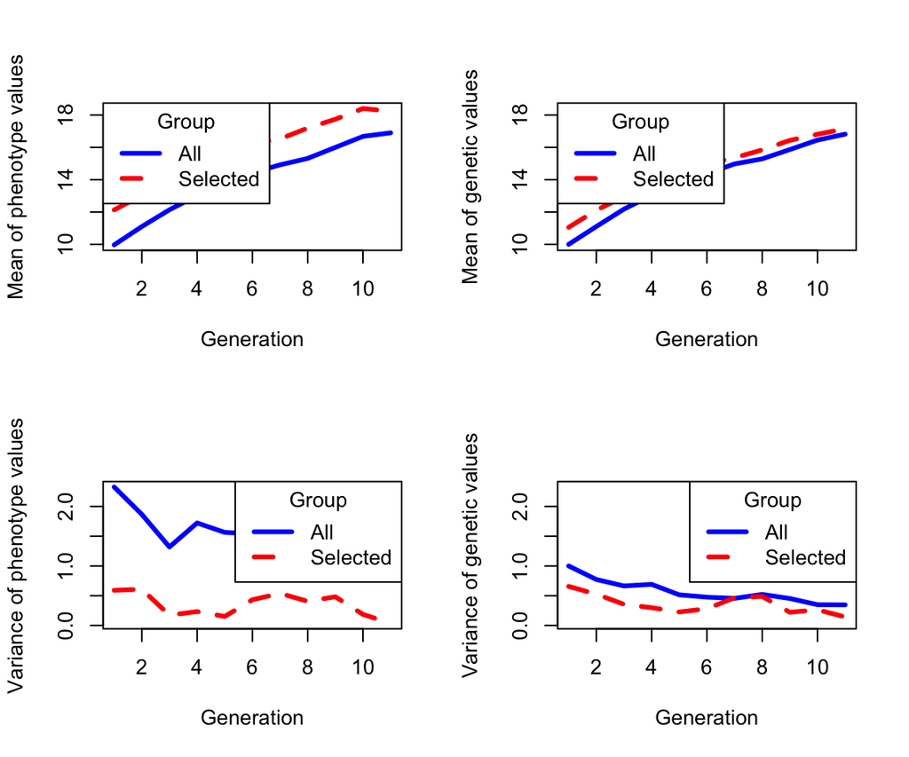

```r
# Some plots
meanRanges = range(c(meanPAll, meanPSelected, meanGAll, meanGSelected))
varRanges = range(c(varPAll, varPSelected, varGAll, varGSelected))

par(mfrow = c(2, 2))

# Plot mean of phenotype values over time
plot(x = 1:nGenerations, y = meanPAll, type = "l", col = "blue", lwd = 3,
     xlab = "Generation", ylab = "Mean of phenotype values", ylim = meanRanges)
lines(x = 1:nGenerations, y = meanPSelected, type = "l", col = "red", lty = 2, lwd = 3)
legend(x = "topleft", legend = c("All", "Selected"), title = "Group",
       lwd = 3, lty = c(1, 2), col = c("blue", "red"))

# Plot mean of genetic values over time
plot(x = 1:nGenerations, y = meanGAll, type = "l", col = "blue", lwd = 3,
     xlab = "Generation", ylab = "Mean of genetic values", ylim = meanRanges)
lines(x = 1:nGenerations, y = meanGSelected, type = "l", col = "red", lty = 2, lwd = 3)
legend(x = "topleft", legend = c("All", "Selected"), title = "Group",
       lwd = 3, lty = c(1, 2), col = c("blue", "red"))

# Plot variance of phenotype values over time
plot(x = 1:nGenerations, y = varPAll, type = "l", col = "blue", lwd = 3,
     xlab = "Generation", ylab = "Variance of phenotype values", ylim = varRanges)
lines(x = 1:nGenerations, y = varPSelected, type = "l", col = "red", lty = 2, lwd = 3)
legend(x = "topright", legend = c("All", "Selected"), title = "Group",
       lwd = 3, lty = c(1, 2), col = c("blue", "red"))

# Plot variance of genetic values over time
plot(x = 1:nGenerations, y = varGAll, type = "l", col = "blue", lwd = 3,
     xlab = "Generation", ylab = "Variance of genetic values", ylim = varRanges)
lines(x = 1:nGenerations, y = varGSelected, type = "l", col = "red", lty = 2, lwd = 3)
legend(x = "topright", legend = c("All", "Selected"), title = "Group",
       lwd = 3, lty = c(1, 2), col = c("blue", "red"))
```

**Interpretation**

- In this very simple scenario we can see some important trends when breeders are performing selection:
  - Increase the phenotypic mean
  - Reduce the variability

# Conclusions

Along this course we are emphasizing the importance on use computer (software) for analyses. We introduced the R language and its potential for data wrangling and analyses using linear models. In the sequence, we presented the `asreml-R` package for more specialized analyses. Herein, we focused on simulations. `AlphaSimR` is a good tool for any breeding program that intend to test new ideas and concept in a real breeding program. Package is also relevant for statistic modelling. For example, when investigating new models and software, it is an important exercise to create a simulated scenario where we can try to predict a known scenario and consequently check the quality of our implementation.

# References

- Gaynor et al., (2021). AlphaSimR: an R package for breeding program simulations. [Link for the paper](https://academic.oup.com/g3journal/article/11/2/jkaa017/6025179)
- Most of the codes here used was inspired in the materials prepared by [Leticia Lara](https://github.com/leticia-lara)